# American Journal of Botany

[American Journal of Botany](https://bsapubs.onlinelibrary.wiley.com/journal/15372197)

[Volume 98, Issue 10](https://bsapubs.onlinelibrary.wiley.com/toc/15372197/2011/98/10) p. 1727-1734

[figure not shown]

Brief Communication

Free Access

# Edge effects on growth and biomass partitioning of an Amazonian understory herb (*Heliconia acuminata*; Heliconiaceae)†

[Emilio M. Bruna](https://bsapubs.onlinelibrary.wiley.com/action/doSearch?ContribAuthorRaw=Bruna%2C+Emilio+M),

[Ana Segalin de Andrade](https://bsapubs.onlinelibrary.wiley.com/action/doSearch?ContribAuthorRaw=Andrade%2C+Ana+Segalin),

First published: 01 October 2011

https://doi.org/10.3732/ajb.1000290

Citations: 3

Check for Full Text

†

## Abstract

• *Premise:* After deforestation, environmental changes in the remaining forest fragments are often most intense near the forest edge, but few studies have evaluated plant growth or plasticity of plant growth in response to edge effects.

• *Key results:* Genetically identical plants transplanted to the forest edge and understory exhibited different patterns of growth and biomass allocation. However, individuals with identical genotypes in the same garden often had very different responses. Plants on forest edges also had higher growth rates and increased biomass at the end of the experiment, almost certainly due to the increased light on the forest edge.

• *Conclusions:* With over 70000 km of forest edge created annually in the Brazilian Amazon, phenotypic plasticity may play an important role in mediating plant responses to these novel environmental conditions.

Forests are heterogeneous environments, with locally variable canopy cover, plant density, and soil properties. Superimposed on this heterogeneity are changes resulting from human activities such as deforestation and fragmentation (reviewed in 36). Among the most notable of these changes, particularly in tropical forests, are those in abiotic conditions. For instance, studies have documented reduced soil moisture and relative humidity, increased air temperatures, and elevated penetration of photosynthetically active radiation (PAR) in the understory with increasing proximity to forest edges (32; 14; 19; 48). Because the intensity of these changes can increase with proximity to forest edges, they are referred to as edge effects (reviewed in 7).

Abiotic edge effects are often posited as important mechanisms driving the mortality of understory or shade-tolerant plants in tropical forest fragments (36; 30). For instance, much of the dramatically elevated mortality of trees within 100 m of forest edges in central Amazonia has been attributed to “sudden shifts in temperature, relative humidity, or soil moisture [that] exceeded their physiological tolerances” (35, p. 2036). In addition, abiotic edge effects could influence the growth of individuals that survive the process of edge creation (33). Plants exposed to xeric conditions often shift resources belowground to enhance the uptake of water and nutrients; they may also shed leaves and thicken remaining ones (11) to minimize the water loss that accompanies elevated evapotranspiration. These changes elevate the root to shoot ratio (R:S ratio), reduce specific leaf area (SLA), lower leaf area ratio (LAR), and could ultimately reduce growth rates and plant biomass.

Despite the potential for edge effects to influence plant growth, most studies investigating edge effects have evaluated their impact on plant recruitment or mortality (reviewed in 10). Those studies that have focused on growth have been conducted primarily with woody plant species, and the results are often contradictory. For instance, while some have found plant growth is depressed near edges (27; 11), others have found that plants near edges grow much more rapidly than those in forest interiors (54). Other studies have found that seedling growth is independent of fragment size (8) or most strongly influenced by environmental conditions in the microsites where seedlings are growing (42; 2; Lopez-Barrera et al., 2006).

One important factor that has been overlooked in previous studies of fragmentation and plant growth is phenotypic plasticity, which is the property of a genotype to produce different physiological or morphological phenotypes in response to shifting environmental conditions (reviewed in 51; 13). Populations of species adapted to narrow ranges of environmental conditions, i.e., those with low phenotypic plasticity in selectively important characters, might be at a higher risk of local extinction in changing environments (60) such as forest edges. Conversely, plasticity could allow for some individuals on forest edges to, for example, respond favorably to the drier and hotter conditions there (e.g., with increased growth or reproduction) even as other individuals are detrimentally affected. To our knowledge, however, no studies explicitly tested for phenotypic plasticity in responses to edge effects.

Here we present the results of a 2-year experiment in which we transplanted genetically identical plants to common gardens located on a forest edge and the forest interior. We addressed the following questions: (1) Do plants in the interior and edge show contrasting patterns of plant growth and biomass allocation consistent with edge effects? (2) How variable are responses within and between genotypes, i.e., is there evidence for phenotypic plasticity and genotype × environment interactions? We used as a study system the understory herb (*Heliconia acuminata* L. C. Richard; Heliconiaceae), whose growth responses to fragmentation have been intensively studied (8; 11; 12; 26).

## MATERIALS AND METHODS

### Study site and system

The Biological Dynamics of Forest Fragments Project (BDFFP) is a 1000-km<sup>2</sup> mosaic of lowland forest, forest fragments, secondary forests, and pastures located ca. 70 km north of Manaus, Brazil (2°30′S, 60°W). Soils at the site are nutrient-poor oxisols, which despite their high clay content have poor water-retention capacity (22). Mean annual temperature is 26°C (range 19–39°C), and mean annual rainfall ranges from 1900–2300 mm with a pronounced dry season from June to December. A complete summary of the BDFFP can be found in 4.

*Heliconia acuminata* (Heliconiaceae) is a self-incompatible, perennial herb widely distributed throughout the Amazon basin (3). It grows by producing shoots from a rhizome and reproduces primarily via seed (9), although it can be propagated by segmentation of the rhizome for horticultural purposes (3). Although many species of *Heliconia* grow in large aggregations on roadsides, gaps, and disturbed habitats, *H. acuminata* is found primarily in the shaded forest understory, both at the BDFFP (12; 49) and in other tropical locations (3).

### Experimental design

On 6 February 2004, we randomly selected 19 of the genotypes for which there were at least six clones. We then immediately transplanted three randomly selected clones of each genotype to each of two common gardens (3 clones per genotype × 19 genotypes = 57 plants per garden). These gardens were located in an expanse of forest near BDFFP Reserve No. 2206, with one located on a forest edge adjacent to a pasture created in 1984 and the second 500 m away in a continuous, closed-canopy forest (online Appendix S2). The pasture was originally created by burning felled logs, and parts of the pasture were burned again in 1989, 1990, 1992, and 1994 (BDFFP Records). Although there has been some regeneration along the forest edge, the pasture grass has inhibited the regeneration of encroaching secondary forest (E. Bruna and A. Andrade, personal observations). Each of the gardens was 50 × 35 m; the garden on the forest edge was arranged 15 m from the forest–pasture border with the 50 m side parallel to the edge. This placement ensured that the entire edge garden was exposed to relatively similar edge effects, which can extend 50–100 m from the forest edge, while avoiding the narrow band (up to 10 m from the edge) where there is a severe edge-dependent gradient in abiotic changes (reviewed in 7).

The common gardens are similar in slope, aspect, and elevation. Even though the BDFFP's experimentally isolated fragments are protected from fire, the presence of charred logs, soil charcoal, a less sparse and diverse understory community, and *Vismia* spp. in the overstory of our edge garden (E. Bruna and A. Andrade, personal observations) suggests that the forest edge had been affected by fire that had been used to clear the adjacent pastures (sensu 49). We found notable differences in soil chemistry among gardens (See Results).

An important advantage of our design is that having three clones of each genotype in a garden allows us to quantify variation in a genotype's response to variation in the environmental conditions in the garden. However, the effort required to generate sufficient clones of this slow-growing species precluded us from having sufficient replicates of each genotype to establish multiple gardens in each habitat type. The differences in abiotic conditions (Results, online Appendix S3) and forest structure (E. Bruna and A. Andrade, personal observations) among the gardens on the forest edge and interior are consistent with those observed in other studies of edge effects in the BDFFP landscape (reviewed in 36). Nevertheless, because it is possible that the responses we observed result from intergarden differences not directly related to edge proximity (31), we are cautious in extrapolating our results beyond these gardens.

Transplant date corresponded with the onset of the rainy season to minimize transplant shock. Plants assigned to each garden were arranged 5 m apart on seven transects parallel to the forest edge; plants were assigned to points at random, and transects were separated from each other by 7 m. At the time of transplanting, we individually marked every leaf with a numbered plastic tag (0.5 × 1.0 cm) attached to the petiole with telephone wire. We also measured the length of every leaf and calculated its area using a previously published regression equation (11). At the time of transplanting, there was no significant difference in the leaf area of plants assigned to the different gardens (*t* = 1.05, df = 112, *P =* 0.3, Fig. 1A).

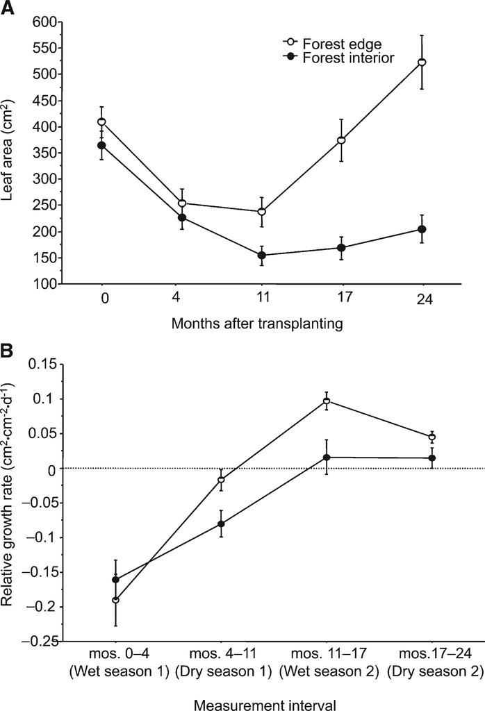

**Figure 1**

All surviving plants were removed from the ground immediately after the final measurement (17 January 2006), when we separated the above- and belowground portions of each plant and dried them at 60°C to a constant mass. We then pooled and weighed stems and rhizome/roots, as well as each individual leaf, to the nearest 0.002 g with an Ohaus Navigator Balance (Pine Brook, New Jersey, USA). Using these weights and the estimates of final leaf area, we calculated the following metrics of biomass allocation: total biomass (total biomass = root biomass + rhizome biomass + stem biomass + leaf biomass), ratio of below- to aboveground biomass (B-A ratio = belowground biomass/aboveground biomass), specific leaf area (SLA = leaf area/leaf mass), and the leaf area ratio (LAR = total leaf area/total plant mass). We also calculated the relative growth rate of plants during each rainy and dry season as RGR = [ln(leaf area at *t*<sub>2</sub>) − ln(leaf area at *t*<sub>1</sub>)] / (*t*<sub>2</sub> − *t*<sub>1</sub>).

We quantified daily fluctuation in abiotic conditions in the center of common gardens from February 2004 to January 2006. Relative humidity (%) and air temperature (°C) were recorded every 30 min using a HOBO Pro Series automated temperature and humidity sensor (Cape Cod, Massachusetts, USA) located in the center of each plot. Soil moisture (m<sup>3</sup>/m<sup>3</sup>) and photosynthetic photon flux density (PPFD, µmol·m<sup>−2</sup>·s<sup>−1</sup>) were recorded with Onsett Smart Sensors connected to Microstation dataloggers (model numbers S-SMA-M003, S-LIA-M003, and H21-002 respectively; Onsett Corp., Bourne, Massachusetts, USA); measurements were collected every 30 s for 30 min and the 30-min means were recorded for use in analyses (again, one sensor was located in the center of each plot). We used the mean PFFD values to calculate total daily PPFD (mol·m<sup>−2</sup>·d<sup>−1</sup>).

We also collected soil cores from the base of each plant to compare soil properties in the two gardens. The cores were 10 cm deep and were collected from a randomly selected point no more than 20 cm from the base of the plant, which is the zone to which where the roots of *H. acuminata* are typically limited (E. Bruna and A. Andrade, personal observations). These soils were air dried in an air-conditioned laboratory for 48 h and then analyzed by the Soil Chemistry Laboratory at EMBRAPA Amazônia Ocidental (Manaus, Brazil), where the following properties were quantified using standard protocols (20): organic matter, % N, P, K<sup>+</sup>, Na<sup>+</sup>, Ca<sup>2+</sup>, Mg<sup>2+</sup>, Al<sup>3+</sup>, percentage base saturation, Fe, Zn, Mn, Cu, total C, and pH.

### Statistical analyses

We compared the survivorship of plants in the two gardens using a *G* test. We then used a repeated-measures analysis of variance (ANOVA) to compare changes in leaf area and the relative growth rates of surviving plants in the two gardens at each rainy-season–dry-season transition. The dependent variables were total leaf area and RGR, with genotype and habitat type (i.e., forest edge, forest interior) included as main effects and initial leaf area included as a covariate. To compare patterns of biomass allocation in the gardens, we plotted reaction norms (52) and used a two-way ANOVA to test for a significant interaction between the main effects, genotype and habitat type (i.e., forest edge and interior). Clone was nested within genotype, and the dependent variables were B-A ratio, SLA, LAR, and final total biomass. Variables were square-root or log-transformed as necessary to meet the assumptions of parametric statistics; throughout the text and in figures, we provide back-transformed values for all variables. Two genotypes were excluded because only one of the clones in one of the gardens survived the experiment; an additional genotype was excluded from the analysis of SLA because its only leaf had been fully expanded for less than 1 wk.

Finally, we used nonmetric multidimensional scaling (NMDS) to quantify the differences in soils among gardens. NMDS is an iterative best-fit ordination technique that arranges samples so that the distance between them in ordination space is in rank order with their similarity. We used the Sorensen (Bray–Curtis) distance metric as a measure of dissimilarity, with Monte Carlo tests (1000 randomized runs) to assess significance. We then used Mann–Whitney *U* tests to compare soil properties on the edge and interior gardens and linear regression to determine whether there was a relationship between a plant's relative growth rate over the course of the study and the axis 1 score for the soil core collected at its base. The NMDS was conducted in the program PC-ORD (41); all other analyses were done in the program SYSTAT (56).

## RESULTS

The gardens have distinct soil characteristics, as indicated by the NMDS ordination (online Appendix S4). The final stress value for a two-dimensional solution was 8.75, with the first axis explaining most of the variation in the data set (*r*<sup>2</sup><sub>Axis 1</sub> = 0.889, *r*<sup>2</sup><sub>Axis 2</sub> = 0.078). Though both gardens have the low pH, high aluminum, and limited nutrients common in central Amazonian oxisols (22), the garden on the edge had significantly more micronutrients, organic matter, P, K<sup>+</sup>, and higher % N (online Appendix S5; see Appendix S6 for correlations of the soil properties with axis scores).)

During the dry season, the midday temperature on the forest edge was ca. 2.4°C higher than in the forest interior, while relative humidity was ca. 15% lower (Appendix S3). Light levels were also very different in the two gardens. Maximum daily PPFD was up to 3-fold higher on the forest edge than forest interior during the dry season (108 µmol·m<sup>−2</sup>·s<sup>−1</sup> at 1100 hours vs. 35.93 µmol·m<sup>−2</sup>·s<sup>−1</sup> at 1300 hours), with comparable differences in the estimates of total daily PPFD (forest edge: 1.605 mol/m<sup>2</sup>, forest interior: 0.607 mol/m<sup>2</sup>). Relative differences in PPFD were similarly pronounced during the wet season, although overall PPFD was lower. Soil moisture on the forest edge was about 60% of that in the forest interior (0.06 m<sup>3</sup>/m<sup>3</sup> vs. 0.1 m<sup>3</sup>/m<sup>3</sup>, respectively), with little temporal variation (Appendix S3).

| Source | df | MS | *F* | *P* |
| --- | --- | --- | --- | --- |
| Between subjects |  |  |  |  |
| Habitat | 1 | 1263.60 | 10.26 | **0.002** |
| Genotype | 18 | 112.60 | 0.91 | 0.57 |
| Habitat × genotype | 18 | 72.66 | 0.59 | 0.89 |
| Initial leaf area | 1 | 2814.13 | 22.856 | **<0.001** |
| Error | 52 | 123.13 |  |  |
| Within subjects |  |  |  |  |
| Time | 3 | 2.47 | 0.24 | 0.87 |
| Time × habitat | 3 | 216.86 | 21.03 | **<0.001** |
| Time × genotype | 54 | 10.60 | 1.03 | 0.44 |
| Time × habitat × genotype | 54 | 6.03 | 0.56 | 0.99 |
| Time × Initial leaf area | 3 | 7.36 | 0.71 | 0.55 |
| Error | 156 | 10.31 |  |  |

Table 2. Repeated-measures ANOVA for the effect of habitat type (forest edge or interior) and genotype on the relative growth rate of *Heliconia acuminata*clones transplanted to common gardens. Growth rates were calculated for each rainy and dry season for 2 years. The leaf area of plants at the time they were transplanted was included as a covariate; significant effects are in boldface.

| Source | df | MS | *F* | *P* |
| --- | --- | --- | --- | --- |
| Between subjects |  |  |  |  |
| Habitat | 1 | 0.09 | 6.79 | **0.01** |
| Genotype | 18 | 0.01 | 0.72 | 0.77 |
| Habitat × genotype | 18 | 0.01 | 0.73 | 0.75 |
| Initial leaf area | 1 | 0.001 | 0.08 | 0.78 |
| Error | 48 | 0.014 |  |  |
| Within subjects |  |  |  |  |
| Time | 3 | 0.12 | 5.26 | **0.002** |
| Time × habitat | 3 | 0.06 | 2.42 | 0.07 |
| Time × genotype | 48 | 0.03 | 1.44 | **0.05** |
| Time × habitat × genotype | 48 | 0.02 | 0.85 | 0.74 |
| Time × initial leaf area | 3 | 0.003 | 0.13 | 0.94 |

The average final biomass of *Heliconia acuminata* transplanted to the forest edge was double that of plants transplanted to the forest interior (mean = 10.4 g ± 8.0 SD vs. 4.6 g ± 3.2 SD, respectively), a highly significant difference (*F*<sub>1,57</sub> = 14, *P <* 0.001). The variable slopes and overlapping reaction norms were consistent with both intergenotypic variation in growth responses and genotype × environment interactions (Fig. 2A). However, there was no significant effect of genotype or significant genotype × habitat interaction in our ANOVA (Table 3). Final biomass of plants from the garden on the forest edge was more variable than that of plants grown in the interior (range = 0.36–31.49 g vs. 0.15–12.44 g, respectively).

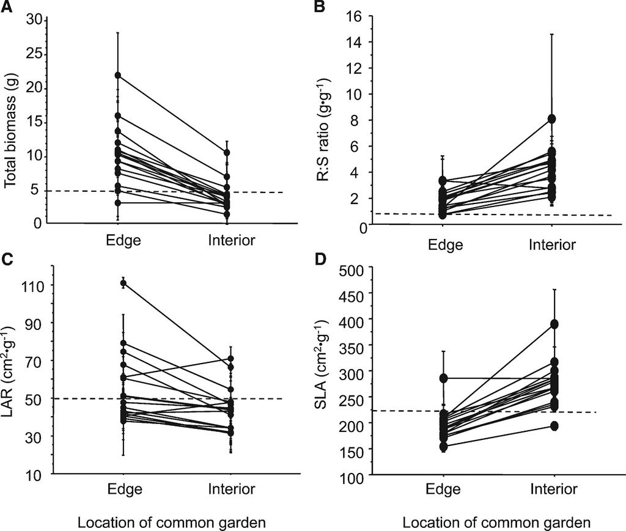

**Figure 2**

Table 3. ANOVAs for the effect of habitat (forest edge or interior) and genotype on biomass partitioning of clones of the Amazonian understory herb *Heliconia acuminata*. Measurements were made 24 months after transplanting; significant effects are in boldface.

| Source | df | MS | *F* | *P* | Source | df | MS | *F* | *P* |
| --- | --- | --- | --- | --- | --- | --- | --- | --- | --- |
| Sqrt (Final biomass) (g) |  |  |  |  | Leaf area ratio (cm<sup>2</sup>·g<sup>−2</sup>) |  |  |  |  |
| Habitat | 1 | 13.65 | 14 | **<0.001** | Habitat | 1 | 2592.80 | 8.10 | **0.006** |
| Genotype | 16 | 1.30 | 1.34 | 0.21 | Genotype | 16 | 1016.56 | 3.18 | **0.001** |
| Habitat × genotype | 16 | 0.45 | 0.46 | 0.96 | Habitat × genotype | 16 | 223.99 | 0.70 | 0.78 |
| Error | 57 |  |  |  | Error | 57 | 320.21 |  |  |
| Ln (Ratio of belowground to aboveground biomass) |  |  |  |  | Specific leaf area (cm<sup>2</sup>·g<sup>−2</sup>) |  |  |  |  |
| Habitat | 1 | 16.77 | 31.67 | **<0.001** | Habitat | 1 | 16.52 | 2.98 | 0.09 |
| Genotype | 16 | 0.50 | 0.94 | 0.53 | Genotype | 16 | 30.41 | 5.49 | **<0.001** |
| Habitat × genotype | 16 | 0.15 | 0.28 | 0.99 | Leaf (Clone) | 63 | 10.22 | 1.85 | **<0.001** |
| Error | 57 |  |  |  | Habitat × genotype | 13 | 2.93 | 0.53 | 0.91 |
|  |  |  |  |  | Error | 549 | 5.54 |  |  |

- *Notes:* Leaf area ratio = Leaf area/total plant mass, Specific leaf area = Leaf area/leaf mass

On the forest edge, there was a significant relationship between a plant's RGR and the axis 1 score from the soil core collected at its base (*F*<sub>1,49</sub> = 4.02, MS = 0.009, *P =* 0.05), although the axis score explained only 7.6% of the variance in RGR (RGR = −0.024 + 0.03 × axis 1 score, *r*<sup>2</sup> = 0.076). In continuous forest, the relationship between RGR and the axis 1 score was not significant (*F*<sub>1,46</sub> = 0.097, MS = 0.0002, *P =* 0.76).

## DISCUSSION

### Patterns of biomass partitioning in human-modified landscapes

Higher ratios of belowground to aboveground biomass and lower LAR in the forest interior are consistent with the hypothesis that shade-tolerant species maximize biomass partitioning by allocating to reserve organs, thereby conferring an advantage in low light conditions (5). However, the responses we observed for other metrics of biomass partitioning ran mostly counter to our predictions—previous work, including experiments conducted with *H. acuminata* in nearby forest fragments, suggested understory plants on forest edges should have lower RGR, biomass, LAR, and SLA (11). It may be that in the edge garden, the overall higher levels of nutrients (Appendix S5), for which the underlying mechanisms are unknown, were responsible for the greater growth and biomass accumulation in this site. If so, this increased nutrient availability could lead plants to not only grow more but also increase allocation to biomass that aids in carbon gain. Our results support this hypothesis—by the end of the experiment, plants on the forest edge had twice as many leaves as those in the forest interior, and their leaves were 35% larger.

Nevertheless, elevated soil nutrient levels on forest edges are probably not the primary mechanism underlying greater growth in this garden. Instead, the enhanced growth is almost certainly due to the elevated light to which plants on forest edges are exposed (54; 1; 2). Some shade-tolerant plant species can respond surprisingly well to elevated light environments (46), often exhibiting patterns of growth and physiology comparable to those of gap specialists (61). Furthermore, herbaceous monocots, and in particular *Heliconia*, allocate proportionally more of their aboveground biomass to tissues used for light capture than palms or other understory monocots (50; 17). It is often assumed that the increased light levels on forest edges are so high they will negatively affect forest understory species (e.g., p. 239 in 8; p. 609 in 36), but the levels of PAR and canopy openness recorded in the BDFFP fragments (54; 1; 2) and in our edge site (online Appendix S3) are actually comparable to or even lower than values recorded in the gaps of other tropical forests (e.g., 15; 23; 59; 45). Though edge creation has many negative consequences for plants, increases in light levels appear to be within the physiological limits of both woody (54; 2) and herbaceous (present study) species in these study sites.

Although our results suggest that *H. acuminata* growth is initially enhanced on forest edges, conditions in these sites may nevertheless be detrimental to plants over the long term. *Heliconia* and other understory monocots are relatively intolerant of dry-season water stress (55), and soil moisture is often chronically low on forest edges (32; 14; Appendix S3). In addition, by the end of the experiment, the leaves of plants on forest edges often had the yellowing characteristic in *Heliconia* of photoinhibition (28, 29) or attack by pathogens (53). Both of these factors could exacerbate drought sensitivity, lead to leaf loss (39), and increase the risk of plant mortality. It is worth noting that, while the plant growth rate on the edge was positive from the third to the fourth interval, it was actually declining. In contrast, growth in the forest interior remained positive and constant (Fig. 1B).

### Future directions

Over 70000 km of new forest edges are being created annually in the Brazilian Amazon by human activities (7). Our results highlight the risk in assuming that alterations in abiotic conditions associated with edge creation are uniformly negative for plants (e.g., 36), and instead demonstrate that forms of land use generally considered detrimental can actually enhance plant performance (e.g., Fraterrigo et al., 2004; Endels et al., 2006). The difference in growth rates among years also underscores the difficulty in predicting plant responses to landscape alterations without long-term and experimental studies. Given that our study was conducted at one pair of sites along one edge, we propose that an important next step is to document how patterns of plant growth vary between edges to better understand the influence of factors such as edge age and aspect (37), the structure of the regenerating vegetation abutting edges (43), local variation in species composition (49), and the synergistic impacts of multiple edges (40). Such studies could greatly contribute to our understanding of the often complex patterns of individual survival and species persistence documented in fragmented landscapes.

## Citing Literature

[figure not shown]

[Volume98, Issue10](https://bsapubs.onlinelibrary.wiley.com/toc/15372197/2011/98/10)

October 2011

Pages 1727-1734

Citation Statements

beta

  Contrasting0

Explore this article's citation statements on [scite.ai](https://scite.ai/reports/edge-effects-on-growth-and-N3lD9Y)

powered by

[figure not shown]

### Metrics

Citations: 3

### Details

© 2011 Botanical Society of America

### Research funding

- NSF. Grant Number: DEB-0309819
- Biological Dynamics of Forest Fragments Project

### Keywords

- [biomass allocation](https://bsapubs.onlinelibrary.wiley.com/action/doSearch?field1=Keyword&text1=biomass%20allocation)
- [common garden](https://bsapubs.onlinelibrary.wiley.com/action/doSearch?field1=Keyword&text1=common%20garden)
- [forest fragmentation](https://bsapubs.onlinelibrary.wiley.com/action/doSearch?field1=Keyword&text1=forest%20fragmentation)
- Heliconiaceae
- [*Heliconia acuminata*](https://bsapubs.onlinelibrary.wiley.com/action/doSearch?field1=Keyword&text1=Heliconia%20acuminata)
- [leaf area ratio](https://bsapubs.onlinelibrary.wiley.com/action/doSearch?field1=Keyword&text1=leaf%20area%20ratio)
- [relative growth rate](https://bsapubs.onlinelibrary.wiley.com/action/doSearch?field1=Keyword&text1=relative%20growth%20rate)
- [specific leaf area](https://bsapubs.onlinelibrary.wiley.com/action/doSearch?field1=Keyword&text1=specific%20leaf%20area)

### Publication History

- Issue Online: 01 October 2011
- Version of Record online: 01 October 2011
- Manuscript accepted: 04 August 2011
- Manuscript received: 02 August 2010

[Download PDF](https://bsapubs.onlinelibrary.wiley.com/doi/pdf/10.3732/ajb.1000290)

back